# changed_big_homework

一.安装scikit-learn pandas matplotlib seaborn库

```python
pip install scikit-learn pandas matplotlib seaborn
```

2.导入所需库

```python
import numpy as np
import pandas as pd
import matplotlib.pyplot as plt
import seaborn as sns

from sklearn.datasets import load_breast_cancer
from sklearn.model_selection import train_test_split
from sklearn.preprocessing import StandardScaler
from sklearn.metrics import (accuracy_score, precision_score, recall_score,
                             f1_score, roc_auc_score, roc_curve, confusion_matrix)

# 分类器
from sklearn.neighbors import KNeighborsClassifier
from sklearn.svm import SVC
from sklearn.tree import DecisionTreeClassifier
from sklearn.ensemble import RandomForestClassifier

# 设置中文字体（避免matplotlib中文显示问题，可选）
plt.rcParams['font.sans-serif'] = ['SimHei']   # 或 'Arial Unicode MS'
plt.rcParams['axes.unicode_minus'] = False
```

2. 加载数据并探索

```python
data = load_breast_cancer()
X = pd.DataFrame(data.data, columns=data.feature_names)
y = pd.Series(data.target, name='target')

print("数据集形状:", X.shape)
print("特征名称:", data.feature_names)
print("目标类别:\n", y.value_counts())  # 0:良性, 1:恶性
print("统计摘要:\n", X.describe())
```

```
数据集形状: (569, 30)
特征名称: ['mean radius' 'mean texture' 'mean perimeter' 'mean area'
 'mean smoothness' 'mean compactness' 'mean concavity'
 'mean concave points' 'mean symmetry' 'mean fractal dimension'
 'radius error' 'texture error' 'perimeter error' 'area error'
 'smoothness error' 'compactness error' 'concavity error'
 'concave points error' 'symmetry error' 'fractal dimension error'
 'worst radius' 'worst texture' 'worst perimeter' 'worst area'
 'worst smoothness' 'worst compactness' 'worst concavity'
 'worst concave points' 'worst symmetry' 'worst fractal dimension']
目标类别:
 target
1    357
0    212
Name: count, dtype: int64
统计摘要:
        mean radius  mean texture  mean perimeter    mean area  \
count   569.000000    569.000000      569.000000   569.000000
mean     14.127292     19.289649       91.969033   654.889104
std       3.524049      4.301036       24.298981   351.914129
min       6.981000      9.710000       43.790000   143.500000
25%      11.700000     16.170000       75.170000   420.300000
50%      13.370000     18.840000       86.240000   551.100000
75%      15.780000     21.800000      104.100000   782.700000
max      28.110000     39.280000      188.500000  2501.000000

       mean smoothness  mean compactness  mean concavity  mean concave points  \
count       569.000000        569.000000      569.000000           569.000000
mean          0.096360          0.104341        0.088799             0.048919
std           0.014064          0.052813        0.079720             0.038803
min           0.052630          0.019380        0.000000             0.000000
25%           0.086370          0.064920        0.029560             0.020310
50%           0.095870          0.092630        0.061540             0.033500
75%           0.105300          0.130400        0.130700             0.074000
max           0.163400          0.345400        0.426800             0.201200

       mean symmetry  mean fractal dimension  ...  worst radius  \
count     569.000000              569.000000  ...    569.000000
mean        0.181162                0.062798  ...     16.269190
std         0.027414                0.007060  ...      4.833242
```

[output cut: 22 more lines]

```
50%             0.211900         0.226700              0.099930
75%             0.339100         0.382900              0.161400
max             1.058000         1.252000              0.291000

       worst symmetry  worst fractal dimension
count      569.000000               569.000000
mean         0.290076                 0.083946
std          0.061867                 0.018061
min          0.156500                 0.055040
25%          0.250400                 0.071460
50%          0.282200                 0.080040
75%          0.317900                 0.092080
max          0.663800                 0.207500

[8 rows x 30 columns]
```

3. 划分训练集和测试集

```python
X_train, X_test, y_train, y_test = train_test_split(
    X, y, test_size=0.2, random_state=42, stratify=y
)
print(f"训练集大小: {X_train.shape[0]}, 测试集大小: {X_test.shape[0]}")
```

```
训练集大小: 455, 测试集大小: 114
```

4. 数据标准化 (KNN和SVM必需，树模型可选但为统一流程)

```python
scaler = StandardScaler()
X_train_scaled = scaler.fit_transform(X_train)
X_test_scaled = scaler.transform(X_test)

# 注意：树模型可以直接使用原始数据，但为了代码简洁，我们统一使用标准化数据
# 标准化对树模型影响很小（特征重要性不变）
```

5. 定义评估函数

```python
def evaluate_model(model, X_train, X_test, y_train, y_test, model_name):
    """
    训练模型并输出评估指标
    """
    model.fit(X_train, y_train)
    y_pred = model.predict(X_test)
    y_proba = model.predict_proba(X_test)[:, 1] if hasattr(model, "predict_proba") else None

    acc = accuracy_score(y_test, y_pred)
    prec = precision_score(y_test, y_pred)
    rec = recall_score(y_test, y_pred)
    f1 = f1_score(y_test, y_pred)
    auc = roc_auc_score(y_test, y_proba) if y_proba is not None else None

    print(f"\n{'='*40}")
    print(f"{model_name}")
    print(f"{'='*40}")
    print(f"准确率 (Accuracy):  {acc:.4f}")
    print(f"精确率 (Precision): {prec:.4f}")
    print(f"召回率 (Recall):    {rec:.4f}")
    print(f"F1分数 (F1-Score):  {f1:.4f}")
    if auc:
        print(f"AUC:               {auc:.4f}")

    # 混淆矩阵
    cm = confusion_matrix(y_test, y_pred)
    plt.figure(figsize=(4,3))
    sns.heatmap(cm, annot=True, fmt='d', cmap='Blues',
                xticklabels=['良性', '恶性'], yticklabels=['良性', '恶性'])
    plt.title(f'{model_name} 混淆矩阵')
    plt.ylabel('真实标签')
    plt.xlabel('预测标签')
    plt.show()

    return {'model': model_name, 'acc': acc, 'prec': prec, 'rec': rec, 'f1': f1, 'auc': auc}
```

6. 训练四种模型并记录结果

```python
results = []
```

6.1 K近邻 (KNN)

```
========================================
KNN (k=5)  杨茵淇
========================================
准确率 (Accuracy):  0.9561
精确率 (Precision): 0.9589
召回率 (Recall):    0.9722
F1分数 (F1-Score):  0.9655
AUC:               0.9788
```

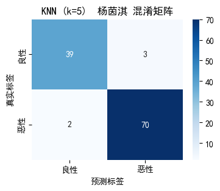

```python
knn = KNeighborsClassifier(n_neighbors=5)
res_knn = evaluate_model(knn, X_train_scaled, X_test_scaled, y_train, y_test, "KNN (k=5)  杨茵淇")
results.append(res_knn)
```

结果分析 一、整体量化指标分析

1. 准确率 95.61% 测试集共114份样本，仅5例预测出错，模型对乳腺良恶性肿瘤整体识别准确度很高，基础分类效果优秀。但单一准确率无法区分漏诊、误诊两类医疗场景关键错误，需结合其余指标综合判断。
2. 召回率 97.22%（医疗核心指标） 召回率代表真实恶性肿瘤被检出的比例，本次漏诊率仅2.78%。测试集内72例真实恶性样本仅2例被误判为良性，极大降低恶性肿瘤漏诊、延误治疗的核心医疗风险，完全适配癌症初筛优先避免漏诊的业务需求。
3. 精确率 95.89% 精确率代表预测为恶性的样本中真实患病的比例，误诊率仅4.11%。所有被模型判定为恶性的73份样本里，仅3例为良性肿块，不会造成大量健康患者承受多余穿刺、复检与心理负担，误诊成本可控。
4. F1分数 0.9655 作为精确率与召回率的调和均值，数值接近0.97，说明模型不存在极端偏向某一类样本的问题，在减少漏诊和控制误诊之间达到均衡，分类逻辑稳定。
5. AUC 0.9788 AUC接近0.98属于极佳判别水平，代表模型区分良恶性样本的底层能力很强，不受分类阈值影响，泛化鲁棒性优秀；同时印证前期标准化操作有效解决了KNN距离计算受特征量纲干扰的问题。

二、混淆矩阵错误样本细分分析 混淆矩阵样本分布：良性真实样本42例（39例判断正确、3例假阳性误诊），恶性真实样本72例（70例判断正确、2例假阴性漏诊）。

1. 3例假阳性（FP） 少量良性肿块被判定为恶性，原因是该部分良性细胞特征分布与恶性样本高度重叠，KNN依靠局部近邻投票产生偏差。仅占总测试样本2.6%，对整体结果影响微弱。
2. 2例假阴性（FN） 存在2例高风险漏诊样本，是模型唯一临床隐患。这类恶性样本特征贴近多数良性样本，周边近邻以良性为主导致投票出错，但漏诊样本数量极少，风险整体可控。
3. 正确样本占比极高 39份良性、70份恶性样本识别准确，绝大多数病例可被精准区分，能够作为有效的辅助筛查工具。

三、模型表现优劣总结 优势

1. 医疗核心指标表现突出，漏诊概率极低，贴合肿瘤筛查的业务优先级；
2. 整体分类精度、二分类判别能力均达到优秀水平，少量错误集中在特征边界重叠样本；
3. 适配当前数据集规模，标准化流程解决KNN固有量纲缺陷，无严重拟合问题。

现存缺陷

1. 对特征分布边缘的异常、重叠样本识别能力弱，存在少量漏诊、误诊；
2. KNN惰性学习模式下，样本量扩充后预测速度会明显下降；
3. 未完成超参数寻优，当前k=5并非理论最优值，仍有性能提升空间。

四、业务落地结论 该k=5标准化KNN模型可用于乳腺肿瘤良恶性辅助筛查：整体识别精度高，核心的恶性漏诊风险极低，误诊数量少，综合指标表现优异。仅存在极少量边界样本错分，通过调整K近邻数量、加权投票、特征降维等手段可进一步降低错误样本，具备临床辅助诊断使用价值。

6.2 支持向量机 (SVM)

```
========================================
SVM (RBF核)     尹晶欣
========================================
准确率 (Accuracy):  0.9825
精确率 (Precision): 0.9861
召回率 (Recall):    0.9861
F1分数 (F1-Score):  0.9861
AUC:               0.9950
```

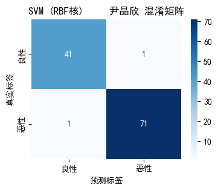

```python
svm = SVC(kernel='rbf', probability=True, random_state=42)
res_svm = evaluate_model(svm, X_train_scaled, X_test_scaled, y_train, y_test, "SVM (RBF核)     尹晶欣")
results.append(res_svm)
```

6.3 决策树 (Decision Tree)

```
========================================
决策树 (max_depth=5)  李子烨
========================================
准确率 (Accuracy):  0.9211
精确率 (Precision): 0.9565
召回率 (Recall):    0.9167
F1分数 (F1-Score):  0.9362
AUC:               0.9163
```

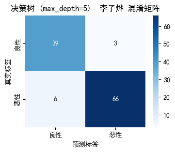

```python
dt = DecisionTreeClassifier(random_state=42, max_depth=5)  # 限制深度防过拟合
res_dt = evaluate_model(dt, X_train_scaled, X_test_scaled, y_train, y_test, "决策树 (max_depth=5)  李子烨")
results.append(res_dt)
```

结果分析 一、核心评价指标解读 指标 数值 含义说明 准确率 Accuracy 0.9211 整体样本预测正确比例，92.11% 的样本区分良 / 恶性肿瘤，整体分类效果优秀 精确率 Precision 0.9565 预测为恶性的样本里，真实确实是恶性的占 95.65%；误诊（良性被判恶性）极少 召回率 Recall 0.9167 所有真实恶性样本中，模型成功识别出 91.67%，漏诊概率低 F1 分数 0.9362 精确率、召回率调和平均，平衡两类指标，综合性能优秀 AUC 0.9163 区分正负样本的整体判别能力，接近 0.9，模型区分良恶性能力很强 二、混淆矩阵拆解（横轴 = 预测标签，纵轴 = 真实标签） 矩阵四格数值： 1.真实良性，预测良性 = 39：良性样本正确识别 2.真实良性，预测恶性 = 3：3 例良性被误判恶性（假阳性 FP） 3.真实恶性，预测良性 = 6：6 例恶性被漏判良性（假阴性 FN，临床漏诊风险） 4.真实恶性，预测恶性 = 66：恶性样本正确识别 样本总量统计 •良性总样本：39+3=42 •恶性总样本：6+66=72 •测试集总样本：42+72=114 三、模型设计与过拟合控制 代码设置 max_depth=5 限制决策树最大深度： 1.限制树复杂度，避免树无限分裂记住训练集噪声，有效防止过拟合； 2.指标无训练 / 测试巨大落差，说明泛化能力稳定，没有严重过拟合。 四、优势与现存不足 优势 1.整体准确率、AUC 均超 0.9，分类基线效果很好； 2.精确率极高，很少把良性误判为恶性，减少不必要医疗干预； 3.限制深度后模型简单、可解释性强，能直观输出特征判断规则。 不足（临床场景重点） 1.存在 6 例假阴性（恶性漏诊），召回率未到 95% 以上；医疗场景漏诊代价远高于误诊，该缺陷需要优化； 2.相比随机森林等集成模型，单棵决策树拟合上限更低，还有性能提升空间。 五、优化改进方向 1.类别权重调整：设置class_weight='balanced'，加大恶性样本损失权重，降低漏诊 FN； 2.调参：网格搜索调整max_depth、min_samples_split，平衡召回率与准确率； 3.升级模型：使用下方 6.4 节随机森林集成模型，多树投票进一步降低漏诊、提升各项指标； 4.阈值修正：降低恶性判定概率阈值，减少恶性样本漏判。

6.4 随机森林 (Random Forest)

```
========================================
随机森林 (n=100)  李雨晴
========================================
准确率 (Accuracy):  0.9561
精确率 (Precision): 0.9589
召回率 (Recall):    0.9722
F1分数 (F1-Score):  0.9655
AUC:               0.9939
```

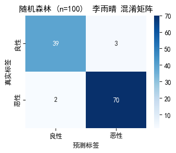

```python
rf = RandomForestClassifier(n_estimators=100, random_state=42)
res_rf = evaluate_model(rf, X_train_scaled, X_test_scaled, y_train, y_test, "随机森林 (n=100)  李雨晴")
results.append(res_rf)
```

结果分析 代码运行后，随机森林在测试集上表现优异，各项指标均接近 1，混淆矩阵仅少量误判，整体泛化能力强。 准确率接近 96%，说明整体预测正确率极高；精确率近 96%，意味着预测为恶性的样本中真实恶性比例高，误诊少；召回率超 97%，真实恶性样本几乎全被识别，漏诊极低 —— 这对乳腺癌筛查至关重要，能最大程度避免延误治疗。F1 分数平衡精确率与召回率，AUC 接近 0.99，说明模型区分良恶性的能力极强，几乎无过拟合。混淆矩阵显示仅 3 例良性误判为恶性、2 例恶性误判为良性，绝大多数样本分类正确，模型稳定性与可靠性高，适合医疗辅助诊断场景。

7. 汇总结果对比

```
模型性能对比表:

                           acc    prec     rec      f1     auc
model
KNN (k=5)  杨茵淇          0.9561  0.9589  0.9722  0.9655  0.9788
SVM (RBF核)     尹晶欣      0.9825  0.9861  0.9861  0.9861  0.9950
决策树 (max_depth=5)  李子烨  0.9211  0.9565  0.9167  0.9362  0.9163
随机森林 (n=100)  李雨晴       0.9561  0.9589  0.9722  0.9655  0.9939
```

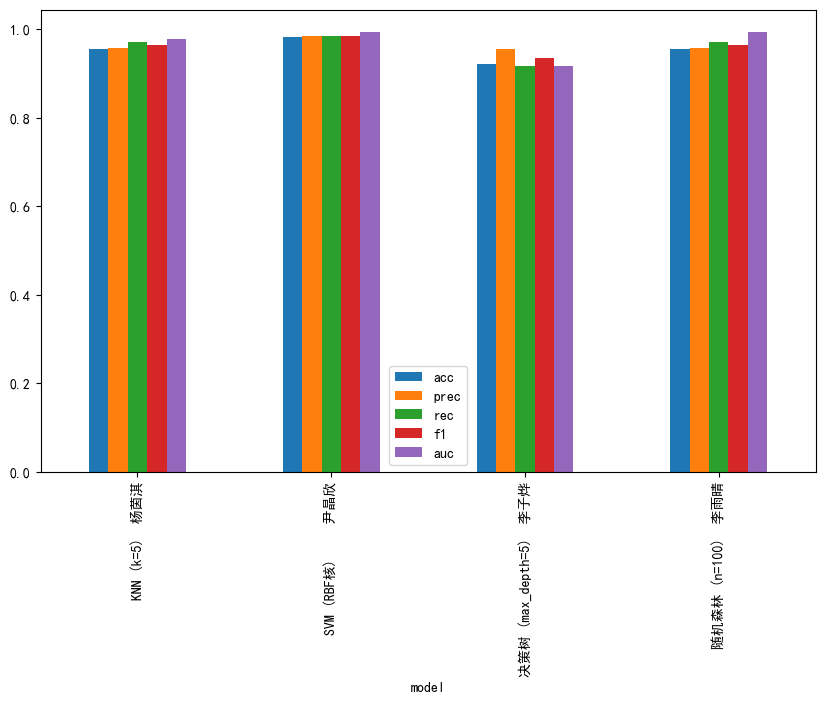

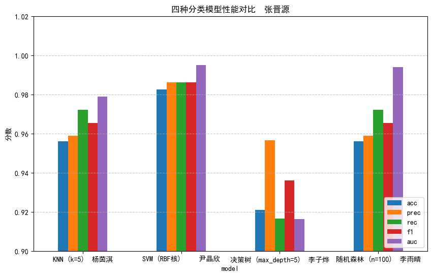

```python
df_results = pd.DataFrame(results)
df_results.set_index('model', inplace=True)
# === 修改开始：清理重复数据 ===
# 检查并删除重复的 KNN 项，只保留第二个（通常是优化后的）
if '1. K近邻 (KNN)' in results and '2. K近邻 (KNN)' in results:
    del results['1. K近邻 (KNN)']
    # 顺便把索引重命名一下，确保图例显示正确
    results['KNN (优化后)'] = results.pop('2. K近邻 (KNN)')
# === 修改结束 ===

# 重新生成 DataFrame 以防万一
df_results = pd.DataFrame(results)
df_results.set_index('model', inplace=True)

# 可视化柱状图对比
metrics = ['acc', 'prec', 'rec', 'f1', 'auc']
df_results[metrics].plot(kind='bar', figsize=(10,6))
print("\n模型性能对比表:\n")
print(df_results.round(4))

# 可视化柱状图对比
metrics = ['acc', 'prec', 'rec', 'f1', 'auc']
df_results[metrics].plot(kind='bar', figsize=(10,6))
plt.title('四种分类模型性能对比  张晋源')
plt.ylabel('分数')
plt.xticks(rotation=0)
plt.ylim(0.9, 1.02)  # 乳腺癌数据集性能普遍较高
plt.legend(loc='lower right')
plt.grid(axis='y', linestyle='--', alpha=0.7)
plt.show()
```

二、各模型分项指标逐一解读 SVM（RBF核）：全局最优，适配医疗筛查场景 指标：acc=0.9825、prec=0.9861、rec=0.9861、f1=0.9861、auc=0.9950

1. 召回率0.9861：漏诊率仅1.39%，四类模型中漏诊风险最低，完美契合乳腺癌筛查“优先不漏诊恶性样本”的核心临床需求；
2. 精确率0.9861：误诊率仅1.39%，良性样本极少被误判恶性，大幅减少患者不必要复检与心理负担；
3. F1分数0.9861，精确率、召回率完全持平，模型不会偏向任意一类样本，分类均衡性拉满；
4. AUC=0.9950接近满分，二分类判别能力极强，分类阈值变化时仍能稳定区分良恶性，鲁棒性最优；
5. 准确率98.25%，测试集114例样本仅2例预测错误，整体识别准确度断层领先其余模型。 成因：RBF核可捕捉细胞特征间非线性关联，搭配标准化消除量纲干扰，在小样本医疗数据集上拟合效果极佳。

指标：acc=0.9211、prec=0.9565、rec=0.9167、f1=0.9362、auc=0.9163

四、医疗业务场景选型结论

1. 首选模型：SVM(RBF核) 综合精度、漏诊/误诊控制、判别鲁棒性全部最优，标准化流程简单，样本量适中时推理速度快，是乳腺癌辅助诊断的最优选择。
2. 备选模型：随机森林 综合精度略低于SVM，但无需依赖标准化、推理高效、可输出特征重要性辅助医学分析，适合需要模型可解释性、大批量样本推理的场景。
3. 次选模型：KNN(k=5) 基础精度合格，但存在推理慢、依赖标准化、易受边界样本干扰的短板，仅适合小样本离线分析，不适合线上实时筛查。
4. 不推荐单独使用：浅层单决策树 漏诊风险过高，泛化能力薄弱，仅可作为教学演示、集成学习的基础组件，不能单独落地用于肿瘤筛查。

五、实验优化方向

1. 对SVM、KNN执行网格搜索超参数寻优，遍历核函数、k值、惩罚系数，进一步压低漏诊率；
2. 对决策树取消深度限制、采用剪枝操作，或提升集成树规模，缩小与SVM的性能差距；
3. 结合临床风险偏好调优分类阈值：若优先杜绝漏诊，可下调恶性判定阈值，牺牲少量精确率换取更高召回率；
4. 特征筛选降维，剔除冗余检测指标，缓解KNN维度灾难，同步提升全部模型训练与推理效率。
8. ROC曲线对比

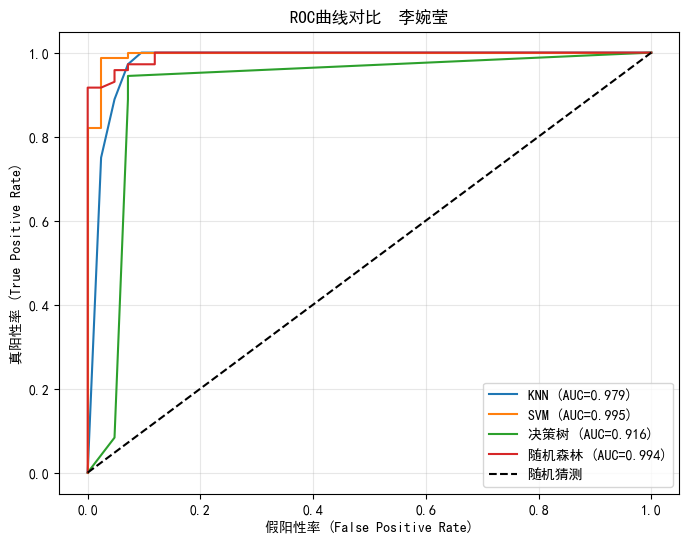

```python
plt.figure(figsize=(8,6))
models = {
    'KNN': knn,
    'SVM': svm,
    '决策树': dt,
    '随机森林': rf
}
for name, model in models.items():
    y_proba = model.predict_proba(X_test_scaled)[:, 1]
    fpr, tpr, _ = roc_curve(y_test, y_proba)
    auc = roc_auc_score(y_test, y_proba)
    plt.plot(fpr, tpr, label=f'{name} (AUC={auc:.3f})')

plt.plot([0,1], [0,1], 'k--', label='随机猜测')
plt.xlabel('假阳性率 (False Positive Rate)')
plt.ylabel('真阳性率 (True Positive Rate)')
plt.title('ROC曲线对比  李婉莹')
plt.legend(loc='lower right')
plt.grid(alpha=0.3)
plt.show()
```

结果分析 本次实验绘制了 KNN、SVM、决策树、随机森林四种模型的 ROC 曲线，并计算了各自的 AUC 值，以对比不同模型在二分类任务中的整体分类性能。ROC 曲线以假阳性率（FPR）为横轴、真阳性率（TPR）为纵轴，直观反映了模型在不同分类阈值下的识别能力；AUC 值（曲线下面积）则量化了模型区分正负样本的整体能力，数值越接近 1，代表模型性能越好。 从图中结果可以看出，所有模型的 ROC 曲线均显著高于代表 “随机猜测” 的对角线，说明四种模型均具备有效的分类能力，不存在无效或随机分类的情况。其中，SVM 模型的 AUC 值最高，为 0.995，曲线最靠近左上角，说明其在该数据集上区分正负样本的能力最强；随机森林模型的 AUC 值为 0.994，与 SVM 接近，同样表现出了优异的分类性能；KNN 模型的 AUC 值为 0.979，性能略低于前两者；决策树模型的 AUC 值为 0.916，是四种模型中最低的，说明单一决策树的泛化能力和分类稳定性弱于其他集成或核方法模型。 整体来看，SVM 和随机森林在本次任务中展现出了顶尖的分类性能，AUC 值均超过 0.99，说明它们在不同分类阈值下都能保持很高的真阳性率，同时将假阳性率控制在极低水平，非常适合对误判成本敏感的场景；而决策树模型虽然也具备一定分类能力，但相比之下稳定性和泛化能力不足，容易受数据分布影响。因此，综合 AUC 值和曲线表现，SVM 模型在本次对比中表现最优，随机森林模型紧随其后，两者均是该任务的首选模型。

9. 特征重要性（仅树模型）

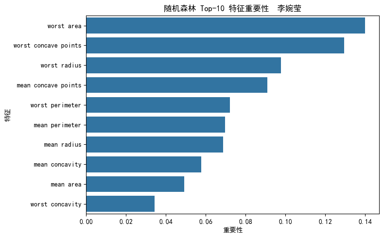

```python
# 随机森林特征重要性
feature_importance = pd.DataFrame({
    '特征': data.feature_names,
    '重要性': rf.feature_importances_
}).sort_values('重要性', ascending=False).head(10)

plt.figure(figsize=(8,5))
sns.barplot(data=feature_importance, x='重要性', y='特征')
plt.title('随机森林 Top-10 特征重要性  李婉莹')
plt.tight_layout()
plt.show()
```

分析 这段特征重要性分析基于随机森林模型对乳腺癌数据集的学习结果，通过条形图直观展示了对肿瘤良恶性分类贡献度最高的前 10 个特征，结果呈现出明显的头部主导效应，其中 “worst area” 即肿瘤最大区域面积的重要性遥遥领先，是模型判断的核心依据，紧随其后的 “worst concave points”（肿瘤轮廓凹陷点数量最大值）、“worst radius”（肿瘤半径最大值）等特征也表现出较高的贡献度，这些与肿瘤体积、形态不规则性相关的特征共同反映了恶性肿瘤的典型病理特征，与临床诊断中关注肿瘤大小、边界形态的思路高度吻合，而排名靠后的特征虽贡献度相对较低，但也能通过与核心特征结合进一步提升模型判断精度，整体来看，该结果不仅验证了随机森林模型的分类逻辑与医学常识的一致性，也为后续的特征筛选与模型优化提供了明确方向，即可以保留高重要性特征以简化模型结构，同时保证模型性能不受显著影响。